# HW2 updated 101525 Yiwei Gu

```r
airlines <- nycflights13::airlines
airports <- nycflights13::airports
flights  <- nycflights13::flights
planes   <- nycflights13::planes
weather  <- nycflights13::weather
```

#1:

```r
library(dplyr)
top_dest <- flights %>%
  group_by(dest) %>%
  summarise(flight_count = n()) %>%
  top_n(10, flight_count) %>%
  arrange(desc(flight_count))
top_dest
```

```
# A tibble: 10 × 2
   dest  flight_count
   <chr>        <int>
 1 ORD          17283
 2 ATL          17215
 3 LAX          16174
 4 BOS          15508
 5 MCO          14082
 6 CLT          14064
 7 SFO          13331
 8 FLL          12055
 9 MIA          11728
10 DCA           9705
```

Ans: The top two popular destinations were Chicago O’Hare and Atlanta Hartsfield-Jackson, each receiving over 17,000 flights. Los Angeles International and Boston Logan also had a high volume, with over 15,000 flights each. Other frequently traveled destinations included Orlando, Charlotte, San Francisco, Fort Lauderdale, Miami, and Washington D.C. (Reagan National).

#2

```r
get_period <- function(time) {
  if (is.na(time)) return(NA_character_)
  hour <- floor(time / 100)
  if (hour >= 0 & hour < 6)  return("early morning")
  if (hour >= 6 & hour < 12) return("morning")
  if (hour >= 12 & hour < 18) return("afternoon")
  if (hour >= 18 & hour <= 23) return("evening")
  return(NA_character_)
}
```

```r
flights_clean <- flights[
  !is.na(flights$dep_time) &
  !is.na(flights$arr_time) &
  floor(flights$dep_time / 100) <= 23 &
  floor(flights$arr_time / 100) <= 23,
]
```

```r
flights_clean$dep_period <- sapply(flights_clean$dep_time, get_period)
flights_clean$arr_period <- sapply(flights_clean$arr_time, get_period)

flights_clean <- flights_clean[!is.na(flights_clean$dep_period) & !is.na(flights_clean$arr_period), ]
```

departure period barplot(exclude NAs):

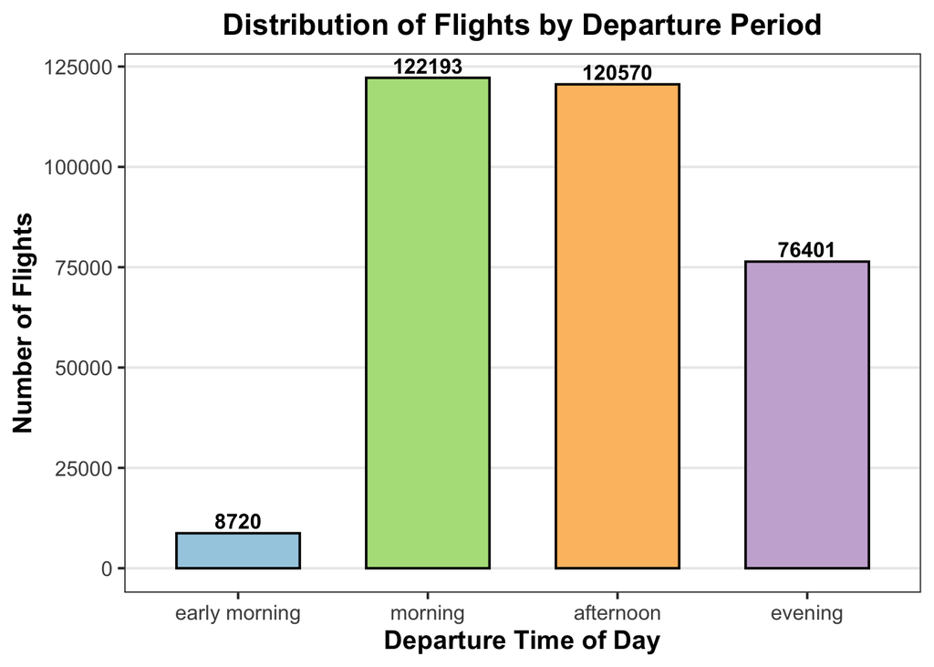

```r
flights_clean$dep_period <- factor(
  flights_clean$dep_period,
  levels = c("early morning", "morning", "afternoon", "evening")
)

flights_clean$arr_period <- factor(
  flights_clean$arr_period,
  levels = c("early morning", "morning", "afternoon", "evening")
)
library(ggplot2)

ggplot(flights_clean, aes(x = dep_period)) +
  geom_bar(aes(fill = dep_period), color = "black", width = 0.65) +
  geom_text(
    stat = "count",
    aes(label = ..count..),
    vjust = -0.3,
    size = 4,
    fontface = "bold"
  ) +
  scale_fill_manual(values = c(
    "early morning" = "#A6CEE3",
    "morning" = "#B2DF8A",
    "afternoon" = "#FDBF6F",
    "evening" = "#CAB2D6"
  )) +
  labs(
    title = "Distribution of Flights by Departure Period",
    x = "Departure Time of Day",
    y = "Number of Flights"
  ) +
  theme_bw(base_size = 14) +
  theme(
    plot.title = element_text(hjust = 0.5, face = "bold", size = 16),
    axis.title = element_text(face = "bold"),
    legend.position = "none",
    panel.grid.minor = element_blank(),
    panel.grid.major.x = element_blank()
  )
```

Arrival Period Barplot (no NAs):

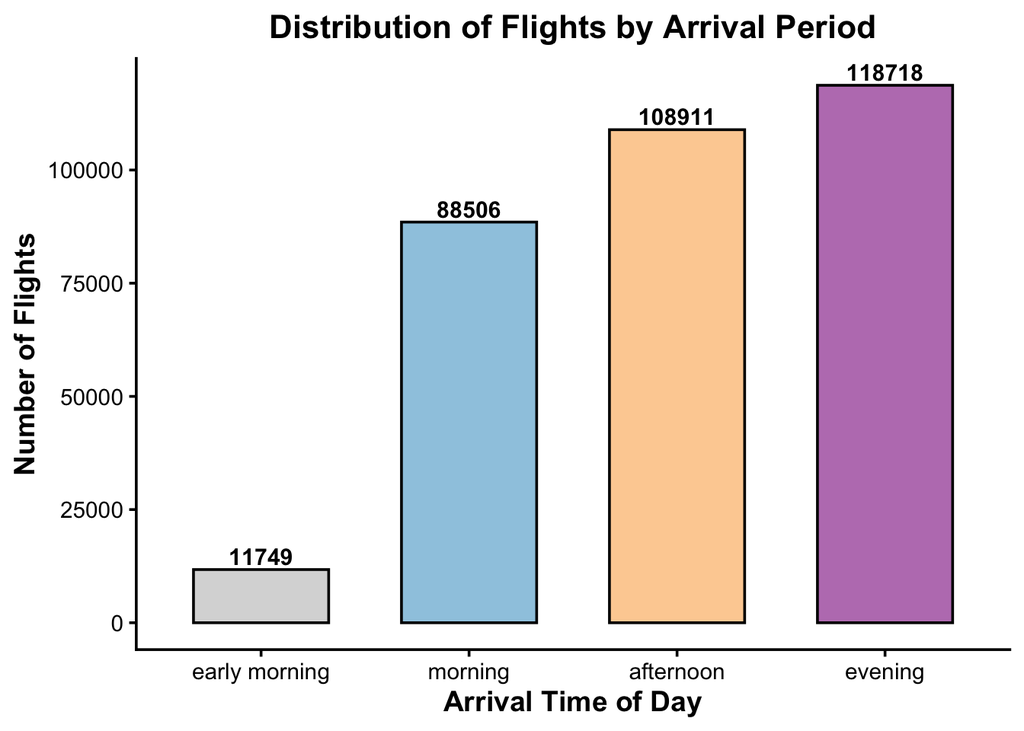

```r
ggplot(flights_clean, aes(x = arr_period)) +
  geom_bar(aes(fill = arr_period), color = "black", width = 0.65) +
  geom_text(
    stat = "count",
    aes(label = ..count..),
    vjust = -0.3,
    size = 4,
    fontface = "bold"
  ) +
  scale_fill_manual(values = c(
    "early morning" = "#D9D9D9",
    "morning" = "#9ECAE1",
    "afternoon" = "#FDD0A2",
    "evening" = "#BC80BD"
  )) +
  labs(
    title = "Distribution of Flights by Arrival Period",
    x = "Arrival Time of Day",
    y = "Number of Flights"
  ) +
  theme_classic(base_size = 14) +
  theme(
    plot.title = element_text(hjust = 0.5, face = "bold", size = 16),
    axis.title = element_text(face = "bold"),
    legend.position = "none"
  )
```

```r
red_eye <- flights_clean[
  flights_clean$dep_period %in% c("afternoon", "evening") &
  flights_clean$arr_period %in% c("early morning", "morning"),
]


red_eye_percent <- nrow(red_eye) / nrow(flights_clean) * 100
red_eye_percent
```

```
[1] 3.234071
```

#3:

```r
library(dplyr)

planes_multi <- flights %>%
  filter(!is.na(tailnum)) %>%
  count(tailnum, carrier) %>%
  group_by(tailnum) %>%
  summarise(
    num_airlines = n(),
    airlines = paste(carrier, collapse = ", ")
  ) %>%
  filter(num_airlines > 1)
```

```r
num_planes <- nrow(planes_multi)
num_planes
```

```
[1] 17
```

```r
planes_multi
```

```
# A tibble: 17 × 3
   tailnum num_airlines airlines
   <chr>          <int> <chr>
 1 N146PQ             2 9E, EV
 2 N153PQ             2 9E, EV
 3 N176PQ             2 9E, EV
 4 N181PQ             2 9E, EV
 5 N197PQ             2 9E, EV
 6 N200PQ             2 9E, EV
 7 N228PQ             2 9E, EV
 8 N232PQ             2 9E, EV
 9 N933AT             2 DL, FL
10 N935AT             2 DL, FL
11 N977AT             2 DL, FL
12 N978AT             2 DL, FL
13 N979AT             2 DL, FL
14 N981AT             2 DL, FL
15 N989AT             2 DL, FL
16 N990AT             2 DL, FL
17 N994AT             2 DL, FL
```

Ans: There were 17 planes that flew for more than one airline in 2013.Delta (DL) and AirTran (FL) — aircraft shared between these carriers Endeavor Air (9E) and ExpressJet (EV) — regional airline partnerships under Delta Connection This overlap likely reflects code-sharing agreements or fleet reassignments under joint airline operations rather than literal transfers between completely separate airlines.

#4: The missing relationship in the diagram is that each weather observation is linked to a specific airport. This relationship exists through the origin field in the weather table, which corresponds to the faa field in the airports table. To represent this in the diagram, an arrow should be drawn from weather.origin to airports.faa. This indicates that each weather record belongs to a specific airport, establishing a foreign key relationship between the two tables.

#5:

```r
names <- c("year", "month", "day", "hour", "origin")

weather$weather_id <- ""

for (var in names) {
  weather$weather_id <- paste0(
    weather$weather_id,
    ifelse(weather$weather_id == "", "", "-"),
    weather[[var]]
  )
}

num_dupes <- sum(duplicated(weather$weather_id))
cat("Number of duplicated weather_id values:", num_dupes, "\n")
```

```
Number of duplicated weather_id values: 3
```

```r
unique(weather$weather_id[duplicated(weather$weather_id)])
```

```
[1] "2013-11-3-1-EWR" "2013-11-3-1-JFK" "2013-11-3-1-LGA"
```

```r
sum(duplicated(weather$weather_id))
```

```
[1] 3
```

```r
table(weather$weather_id[duplicated(weather$weather_id)])
```

```
2013-11-3-1-EWR 2013-11-3-1-JFK 2013-11-3-1-LGA
              1               1               1
```

Ans: after creating a new variable weather_id by combining year, month, day, hour, and origin, I found 3 duplicated weather_id values (2013-11-3-1 at EWR, JFK, and LGA). These duplicates exist because daylight saving time ended on November 3, 2013, causing the 1 AM hour to occur twice. Since we used only year, month, day, hour, and origin, these two distinct 1 AM observations appear as duplicates.

#6:

merge:

```r
flights_weather <- merge(
  x = flights,
  y = weather,
  by = c("time_hour", "origin"),
  all.x = TRUE
)
```

Check the size of the merged data:

```r
dim(flights_weather)
```

```
[1] 336776     33
```

Examine the variables and their types:

```r
str(flights_weather)
```

```
'data.frame':   336776 obs. of  33 variables:
 $ time_hour     : POSIXct, format: "2013-01-01 05:00:00" "2013-01-01 05:00:00" ...
 $ origin        : chr  "EWR" "EWR" "JFK" "JFK" ...
 $ year.x        : int  2013 2013 2013 2013 2013 2013 2013 2013 2013 2013 ...
 $ month.x       : int  1 1 1 1 1 1 1 1 1 1 ...
 $ day.x         : int  1 1 1 1 1 1 1 1 1 1 ...
 $ dep_time      : int  517 554 559 542 544 533 732 629 624 643 ...
 $ sched_dep_time: int  515 558 559 540 545 529 645 630 630 646 ...
 $ dep_delay     : num  2 -4 0 2 -1 4 47 -1 -6 -3 ...
 $ arr_time      : int  830 740 702 923 1004 850 1011 824 909 922 ...
 $ sched_arr_time: int  819 728 706 850 1022 830 941 833 840 940 ...
 $ arr_delay     : num  11 12 -4 33 -18 20 30 -9 29 -18 ...
 $ carrier       : chr  "UA" "UA" "B6" "AA" ...
 $ flight        : int  1545 1696 1806 1141 725 1714 1111 1019 4626 556 ...
 $ tailnum       : chr  "N14228" "N39463" "N708JB" "N619AA" ...
```

[output cut: 19 more lines]

Look at the top and bottom of the dataset:

```r
head(flights_weather)
```

```
            time_hour origin year.x month.x day.x dep_time sched_dep_time
1 2013-01-01 05:00:00    EWR   2013       1     1      517            515
2 2013-01-01 05:00:00    EWR   2013       1     1      554            558
3 2013-01-01 05:00:00    JFK   2013       1     1      559            559
4 2013-01-01 05:00:00    JFK   2013       1     1      542            540
5 2013-01-01 05:00:00    JFK   2013       1     1      544            545
6 2013-01-01 05:00:00    LGA   2013       1     1      533            529
  dep_delay arr_time sched_arr_time arr_delay carrier flight tailnum dest
1         2      830            819        11      UA   1545  N14228  IAH
2        -4      740            728        12      UA   1696  N39463  ORD
3         0      702            706        -4      B6   1806  N708JB  BOS
4         2      923            850        33      AA   1141  N619AA  MIA
5        -1     1004           1022       -18      B6    725  N804JB  BQN
6         4      850            830        20      UA   1714  N24211  IAH
  air_time distance hour.x minute year.y month.y day.y hour.y  temp  dewp humid
1      227     1400      5     15   2013       1     1      5 39.02 28.04 64.43
2      150      719      5     58   2013       1     1      5 39.02 28.04 64.43
3       44      187      5     59   2013       1     1      5 39.02 26.96 61.63
4      160     1089      5     40   2013       1     1      5 39.02 26.96 61.63
5      183     1576      5     45   2013       1     1      5 39.02 26.96 61.63
6      227     1416      5     29   2013       1     1      5 39.92 24.98 54.81
  wind_dir wind_speed wind_gust precip pressure visib     weather_id
1      260   12.65858        NA      0   1011.9    10 2013-1-1-5-EWR
2      260   12.65858        NA      0   1011.9    10 2013-1-1-5-EWR
3      260   14.96014        NA      0   1012.1    10 2013-1-1-5-JFK
4      260   14.96014        NA      0   1012.1    10 2013-1-1-5-JFK
5      260   14.96014        NA      0   1012.1    10 2013-1-1-5-JFK
6      250   14.96014  21.86482      0   1011.4    10 2013-1-1-5-LGA
```

```r
tail(flights_weather)
```

```
                 time_hour origin year.x month.x day.x dep_time sched_dep_time
336771 2013-12-31 22:00:00    JFK   2013      12    31     2218           2219
336772 2013-12-31 23:00:00    EWR   2013      12    31     2328           2330
336773 2013-12-31 23:00:00    JFK   2013      12    31     2355           2359
336774 2013-12-31 23:00:00    JFK   2013      12    31     2356           2359
336775 2013-12-31 23:00:00    JFK   2013      12    31       13           2359
336776 2013-12-31 23:00:00    JFK   2013      12    31       18           2359
       dep_delay arr_time sched_arr_time arr_delay carrier flight tailnum dest
336771        -1      315            304        11      B6   1203  N625JB  SJU
336772        -2      412            409         3      B6   1389  N651JB  SJU
336773        -4      430            440       -10      B6   1503  N509JB  SJU
336774        -3      436            445        -9      B6    745  N665JB  PSE
336775        14      439            437         2      B6    839  N566JB  BQN
336776        19      449            444         5      DL    412  N713TW  SJU
       air_time distance hour.x minute year.y month.y day.y hour.y temp dewp
336771      202     1598     22     19     NA      NA    NA     NA   NA   NA
336772      198     1608     23     30     NA      NA    NA     NA   NA   NA
336773      195     1598     23     59     NA      NA    NA     NA   NA   NA
336774      200     1617     23     59     NA      NA    NA     NA   NA   NA
336775      189     1576     23     59     NA      NA    NA     NA   NA   NA
336776      192     1598     23     59     NA      NA    NA     NA   NA   NA
       humid wind_dir wind_speed wind_gust precip pressure visib weather_id
336771    NA       NA         NA        NA     NA       NA    NA       <NA>
336772    NA       NA         NA        NA     NA       NA    NA       <NA>
336773    NA       NA         NA        NA     NA       NA    NA       <NA>
336774    NA       NA         NA        NA     NA       NA    NA       <NA>
336775    NA       NA         NA        NA     NA       NA    NA       <NA>
336776    NA       NA         NA        NA     NA       NA    NA       <NA>
```

Visualize distributions of key variables

Flight departure delays, Temperature, Wind speed, Precipitation, Visibility

Departure Delay Distribution:

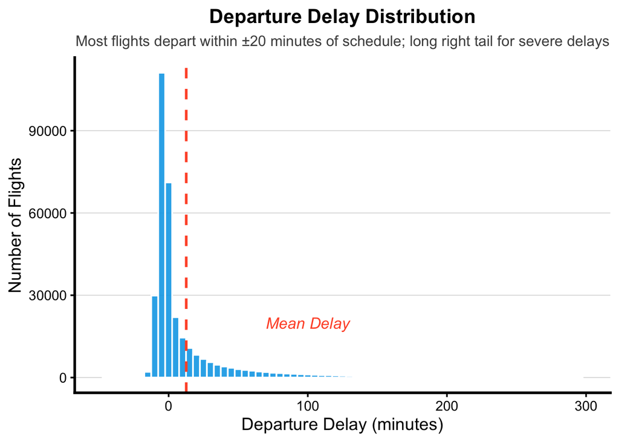

```r
ggplot(flights_weather, aes(x = dep_delay)) +
  geom_histogram(binwidth = 5, fill = "#00A8E8", color = "white", alpha = 0.9) +
  geom_vline(aes(xintercept = mean(dep_delay, na.rm = TRUE)),
             color = "#FF5733", linetype = "dashed", linewidth = 1) +
  annotate("text", x = 100, y = 20000,
           label = "Mean Delay", color = "#FF5733", size = 4.5, fontface = "italic") +
  xlim(-50, 300) +
  labs(
    title = "Departure Delay Distribution",
    subtitle = "Most flights depart within ±20 minutes of schedule; long right tail for severe delays",
    x = "Departure Delay (minutes)",
    y = "Number of Flights"
  ) +
  theme_classic(base_size = 14) +
  theme(
    plot.title = element_text(size = 16, face = "bold", hjust = 0.5),
    plot.subtitle = element_text(hjust = 0.5, size = 12, color = "gray30"),
    axis.line = element_line(size = 1),
    panel.grid.major.y = element_line(color = "gray85", linewidth = 0.3)
  )
```

Temperature Distribution:

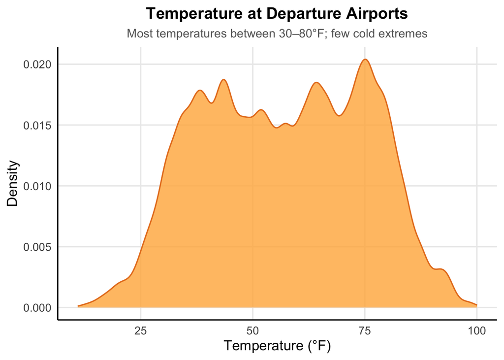

```r
ggplot(flights_weather, aes(x = temp)) +
  geom_density(fill = "#FFB347", color = "#E67E22", alpha = 0.8) +
  labs(
    title = "Temperature at Departure Airports",
    subtitle = "Most temperatures between 30–80°F; few cold extremes",
    x = "Temperature (°F)",
    y = "Density"
  ) +
  theme_minimal(base_size = 14) +
  theme(
    plot.title = element_text(face = "bold", size = 16, hjust = 0.5),
    plot.subtitle = element_text(size = 12, hjust = 0.5, color = "gray40"),
    axis.line = element_line(size = 0.6),
    panel.grid.minor = element_blank()
  )
```

Wind Speed Distribution:

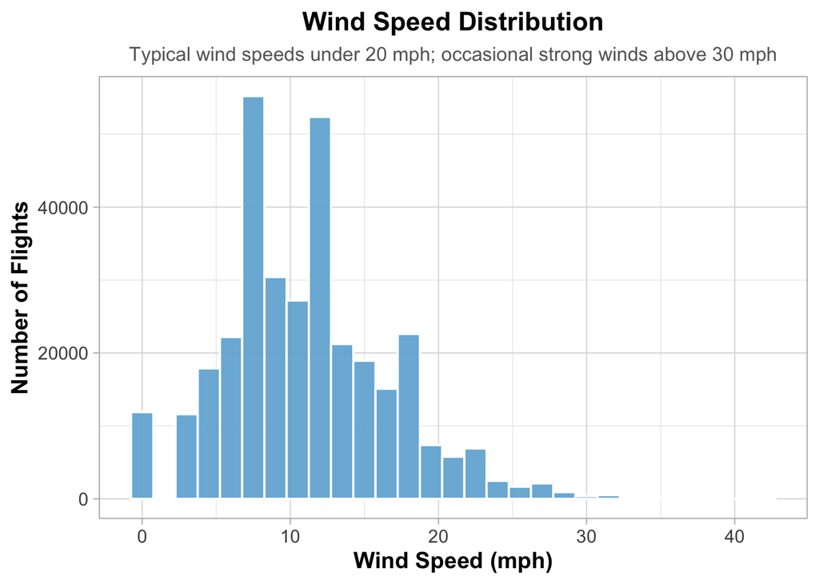

```r
ggplot(flights_weather, aes(x = wind_speed)) +
  geom_histogram(binwidth = 1.5, fill = "#6BAED6", color = "white", alpha = 0.9) +
  labs(
    title = "Wind Speed Distribution",
    subtitle = "Typical wind speeds under 20 mph; occasional strong winds above 30 mph",
    x = "Wind Speed (mph)",
    y = "Number of Flights"
  ) +
  theme_light(base_size = 14) +
  theme(
    plot.title = element_text(size = 16, face = "bold", hjust = 0.5),
    plot.subtitle = element_text(size = 12, hjust = 0.5, color = "gray40"),
    panel.grid.major = element_line(color = "gray85"),
    axis.title = element_text(face = "bold")
  )
```

Visibility Distribution:

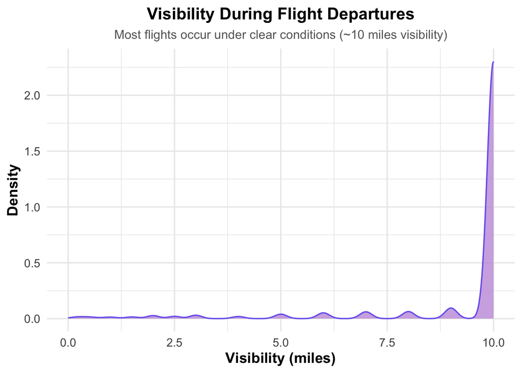

```r
ggplot(flights_weather, aes(x = visib)) +
  geom_density(fill = "#C49CDE", color = "#7B68EE", alpha = 0.8) +
  labs(
    title = "Visibility During Flight Departures",
    subtitle = "Most flights occur under clear conditions (~10 miles visibility)",
    x = "Visibility (miles)",
    y = "Density"
  ) +
  theme_minimal(base_size = 14) +
  theme(
    plot.title = element_text(face = "bold", hjust = 0.5, size = 16),
    plot.subtitle = element_text(size = 12, color = "gray40", hjust = 0.5),
    axis.title = element_text(face = "bold")
  )
```

Precipitation:

[figure not shown]

```r
library(patchwork)
flights_rain <- subset(flights_weather, precip > 0)

p1 <- ggplot(flights_weather, aes(x = precip == 0)) +
  geom_bar(fill = "#5DADE2", color = "black") +
  scale_x_discrete(labels = c("No Precipitation", "With Precipitation")) +
  labs(
    title = "Flights by Precipitation Condition",
    x = NULL,
    y = "Number of Flights"
  ) +
  theme_minimal(base_size = 13) +
  theme(
    plot.title = element_text(face = "bold", hjust = 0.5),
    axis.text = element_text(size = 11),
    axis.title = element_text(face = "bold")
  )


p2 <- ggplot(flights_rain, aes(x = precip)) +
  geom_histogram(binwidth = 0.02, fill = "#2E86C1", color = "black") +
  labs(
    title = "Rainfall Intensity (Rainy Flights)",
    x = "Precipitation (inches)",
    y = "Count"
  ) +
  theme_minimal(base_size = 13) +
  theme(
    plot.title = element_text(face = "bold", hjust = 0.5),
    axis.text = element_text(size = 11),
    axis.title = element_text(face = "bold")
  )

p1 + p2
```

```r
library(dplyr)
cor_data <- flights_weather %>%
  select(dep_delay, temp, wind_speed, visib, precip) %>%
  cor(use = "complete.obs")
round(cor_data, 3)
```

```
           dep_delay   temp wind_speed  visib precip
dep_delay      1.000  0.062      0.047 -0.094  0.090
temp           0.062  1.000     -0.141  0.091  0.010
wind_speed     0.047 -0.141      1.000  0.072  0.033
visib         -0.094  0.091      0.072  1.000 -0.320
precip         0.090  0.010      0.033 -0.320  1.000
```

#7:

average delay by day:

```r
library(dplyr)

avg_day <- flights %>%
  filter(!is.na(dep_delay)) %>%
  group_by(year, month, day) %>%
  summarise(avg_dep_delay = mean(dep_delay, na.rm = TRUE)) %>%
  arrange(desc(avg_dep_delay))
head(avg_day, 5)
```

```
# A tibble: 5 × 4
# Groups:   year, month [4]
   year month   day avg_dep_delay
  <int> <int> <int>         <dbl>
1  2013     3     8          83.5
2  2013     7     1          56.2
3  2013     9     2          53.0
4  2013     7    10          52.9
5  2013    12     5          52.3
```

Ans: 2013-03-08 had the worst average departure delay, with an average of about 83 minutes.Bad weather in early March caused major flight disruptions across New York airports, leading to the longest daily average delay.

Average Delay by Day and Origin:

```r
avg_day_origin <- flights %>%
  filter(!is.na(dep_delay)) %>%
  group_by(origin, year, month, day) %>%
  summarise(avg_dep_delay = mean(dep_delay, na.rm = TRUE)) %>%
  arrange(desc(avg_dep_delay))
head(avg_day_origin, 5)
```

```
# A tibble: 5 × 5
# Groups:   origin, year, month [5]
  origin  year month   day avg_dep_delay
  <chr>  <int> <int> <int>         <dbl>
1 LGA     2013     3     8         106.
2 EWR     2013     3     8          97.8
3 LGA     2013     9     2          80.5
4 LGA     2013    12     5          75.2
5 JFK     2013     7    10          63.6
```

LaGuardia (LGA) on 2013-03-08 had the worst single day, with an average departure delay of about 100 minutes.LaGuardia’s smaller capacity makes it especially vulnerable to weather-related congestion.

Average Delay by Hour and Origin:

```r
avg_hour_origin <- flights %>%
  filter(!is.na(dep_delay)) %>%
  group_by(origin, hour) %>%
  summarise(avg_dep_delay = mean(dep_delay, na.rm = TRUE)) %>%
  arrange(desc(avg_dep_delay))
head(avg_hour_origin, 5)
```

```
# A tibble: 5 × 3
# Groups:   origin [2]
  origin  hour avg_dep_delay
  <chr>  <dbl>         <dbl>
1 EWR       19          31.1
2 EWR       20          27.5
3 EWR       22          26.6
4 EWR       21          26.1
5 JFK       21          26.1
```

#8:

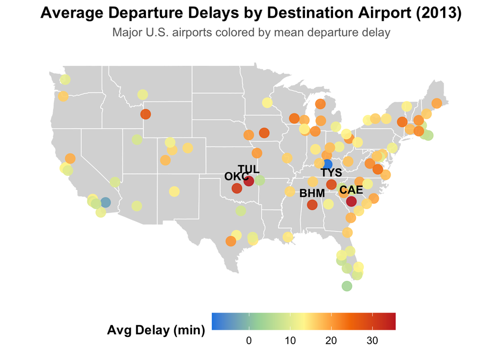

```r
library(dplyr)
library(ggplot2)
library(maps)
library(ggrepel)

avg_delay_dest <- flights %>%
  filter(!is.na(dep_delay)) %>%
  group_by(dest) %>%
  summarise(mean_delay = mean(dep_delay, na.rm = TRUE))

airports_delay <- airports %>%
  inner_join(avg_delay_dest, by = c("faa" = "dest")) %>%
  filter(!is.na(lat), !is.na(lon))


usa <- map_data("state")

top5 <- airports_delay %>%
  top_n(5, mean_delay)

ggplot() +
  geom_polygon(
    data = usa,
    aes(x = long, y = lat, group = group),
    fill = "gray85",
    color = "white",
    linewidth = 0.3
  ) +
  geom_point(
    data = airports_delay,
    aes(x = lon, y = lat, color = mean_delay),
    size = 4.2,
    alpha = 0.9
  ) +
  geom_text(
    data = top5,
    aes(x = lon, y = lat, label = faa),
    vjust = -1,
    fontface = "bold",
    size = 4,
    color = "black"
  ) +
  scale_color_gradientn(
    colors = c("#1E88E5", "#A5D6A7", "#FFF59D", "#F57C00", "#C62828"),
    name = "Avg Delay (min)"
  ) +
  coord_fixed(1.3, xlim = c(-125, -66), ylim = c(25, 50)) +
  labs(
    title = "Average Departure Delays by Destination Airport (2013)",
    subtitle = "Major U.S. airports colored by mean departure delay",
    x = NULL,
    y = NULL
  ) +
  theme_minimal(base_size = 13) +
  theme(
    plot.title = element_text(face = "bold", size = 16, hjust = 0.5),
    plot.subtitle = element_text(size = 12, color = "gray40", hjust = 0.5),
    axis.text = element_blank(),
    panel.grid = element_blank(),
    panel.background = element_rect(fill = "white", color = NA),
    plot.background = element_rect(fill = "white", color = NA),
    legend.position = "bottom",
    legend.title = element_text(face = "bold"),
    legend.key.width = unit(1.3, "cm")
  )
```

#9:

```r
library(nycflights13)
library(dplyr)
library(ggplot2)
library(patchwork)

flights_weather <- merge(
  x = flights,
  y = weather,
  by = c("time_hour", "origin"),
  all.x = TRUE
)

weather_delay <- flights_weather %>%
  select(dep_delay, temp, wind_speed, visib, precip) %>%
  filter(!is.na(dep_delay))

cor_matrix <- round(cor(weather_delay, use = "complete.obs"), 3)
print(cor_matrix)
```

```
           dep_delay   temp wind_speed  visib precip
dep_delay      1.000  0.062      0.047 -0.094  0.090
temp           0.062  1.000     -0.141  0.091  0.010
wind_speed     0.047 -0.141      1.000  0.072  0.033
visib         -0.094  0.091      0.072  1.000 -0.320
precip         0.090  0.010      0.033 -0.320  1.000
```

```r
cor_summary <- data.frame(
  Weather = c("Temperature", "Wind Speed", "Visibility", "Precipitation"),
  Correlation = c(0.062, 0.047, -0.094, 0.090)
)

p_corr <- ggplot(cor_summary, aes(x = reorder(Weather, Correlation), y = Correlation, fill = Correlation)) +
  geom_col(color = "black", alpha = 0.9, width = 0.7) +
  coord_flip() +
  scale_fill_gradient2(low = "#2E86C1", mid = "#FDD835", high = "#E74C3C", midpoint = 0) +
  labs(
    title = "Correlation Between Weather and Departure Delays",
    x = NULL,
    y = "Correlation Coefficient (r)"
  ) +
  theme_minimal(base_size = 14) +
  theme(
    plot.title = element_text(face = "bold", size = 15, hjust = 0.5),
    axis.text = element_text(size = 12),
    panel.grid.minor = element_blank(),
    legend.position = "none"
  )
```

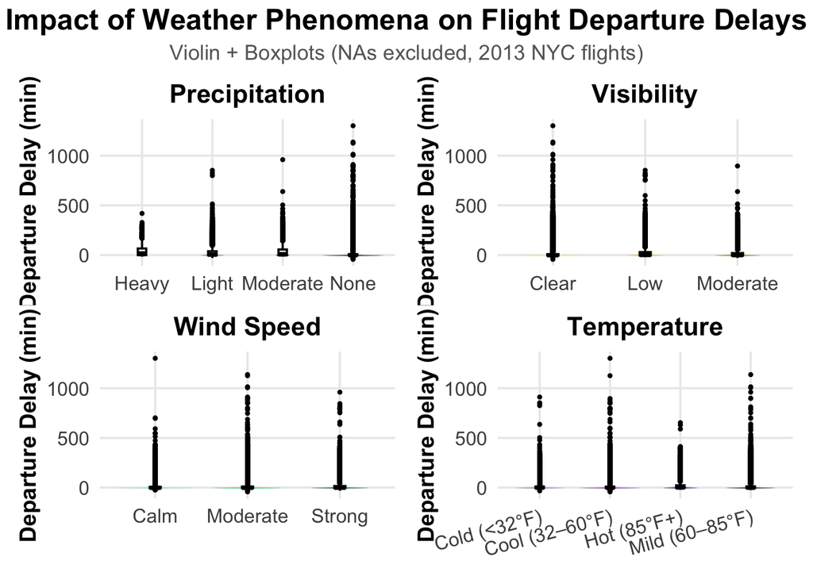

```r
flights_weather <- merge(
  x = flights,
  y = weather,
  by = c("time_hour", "origin"),
  all.x = TRUE
)
weather_delay <- flights_weather %>%
  select(dep_delay, temp, wind_speed, visib, precip) %>%
  filter(!is.na(dep_delay), !is.na(temp), !is.na(wind_speed),
         !is.na(visib), !is.na(precip))


weather_delay <- weather_delay %>%
  mutate(
    precip_cat = case_when(
      precip == 0 ~ "None",
      precip > 0 & precip <= 0.1 ~ "Light",
      precip > 0.1 & precip <= 0.3 ~ "Moderate",
      precip > 0.3 ~ "Heavy"
    ),
    visib_cat = case_when(
      visib >= 8 ~ "Clear",
      visib >= 4 & visib < 8 ~ "Moderate",
      visib < 4 ~ "Low"
    ),
    wind_cat = case_when(
      wind_speed < 5 ~ "Calm",
      wind_speed >= 5 & wind_speed < 15 ~ "Moderate",
      wind_speed >= 15 ~ "Strong"
    ),
    temp_cat = case_when(
      temp < 32 ~ "Cold (<32°F)",
      temp >= 32 & temp < 60 ~ "Cool (32–60°F)",
      temp >= 60 & temp < 85 ~ "Mild (60–85°F)",
      temp >= 85 ~ "Hot (85°F+)"
    )
  )


fancy_theme <- theme_minimal(base_size = 14) +
  theme(
    plot.title = element_text(face = "bold", size = 16, hjust = 0.5),
    axis.title = element_text(face = "bold"),
    axis.text = element_text(size = 12),
    legend.position = "none",
    panel.grid.minor = element_blank(),
    panel.background = element_rect(fill = "white", color = NA),
    plot.background = element_rect(fill = "white", color = NA)
  )

p1 <- ggplot(weather_delay, aes(x = precip_cat, y = dep_delay, fill = precip_cat)) +
  geom_violin(trim = TRUE, alpha = 0.8, color = NA) +
  geom_boxplot(width = 0.12, fill = "white", color = "black", outlier.size = 0.8) +
  scale_fill_manual(values = c("#A7C7E7", "#5DADE2", "#2874A6", "#1B4F72")) +
  labs(title = "Precipitation", x = NULL, y = "Departure Delay (min)") +
  fancy_theme

p2 <- ggplot(weather_delay, aes(x = visib_cat, y = dep_delay, fill = visib_cat)) +
  geom_violin(trim = TRUE, alpha = 0.8, color = NA) +
  geom_boxplot(width = 0.12, fill = "white", color = "black", outlier.size = 0.8) +
  scale_fill_manual(values = c("#F9E79F", "#F4D03F", "#B7950B")) +
  labs(title = "Visibility", x = NULL, y = "Departure Delay (min)") +
  fancy_theme

p3 <- ggplot(weather_delay, aes(x = wind_cat, y = dep_delay, fill = wind_cat)) +
  geom_violin(trim = TRUE, alpha = 0.8, color = NA) +
  geom_boxplot(width = 0.12, fill = "white", color = "black", outlier.size = 0.8) +
  scale_fill_manual(values = c("#ABEBC6", "#58D68D", "#1E8449")) +
  labs(title = "Wind Speed", x = NULL, y = "Departure Delay (min)") +
  fancy_theme

p4 <- ggplot(weather_delay, aes(x = temp_cat, y = dep_delay, fill = temp_cat)) +
  geom_violin(trim = TRUE, alpha = 0.8, color = NA) +
  geom_boxplot(width = 0.12, fill = "white", color = "black", outlier.size = 0.8) +
  scale_fill_manual(values = c("#BB8FCE", "#A569BD", "#7D3C98", "#512E5F")) +
  labs(title = "Temperature", x = NULL, y = "Departure Delay (min)") +
  fancy_theme +
  theme(axis.text.x = element_text(angle = 15, vjust = 1, hjust = 1))

final_fancy_plot <- (p1 + p2) / (p3 + p4) +
  plot_annotation(
    title = "Impact of Weather Phenomena on Flight Departure Delays",
    subtitle = "Violin + Boxplots (NAs excluded, 2013 NYC flights)",
    theme = theme(
      plot.title = element_text(face = "bold", size = 18, hjust = 0.5),
      plot.subtitle = element_text(size = 13, color = "gray40", hjust = 0.5)
    )
  )

print(final_fancy_plot)
```

The violin + boxplot visualization compares flight departure delays under different weather conditions after excluding missing data. Overall, the distributions reveal that precipitation and visibility have the strongest effects on delays, while wind speed and temperature show much smaller influence.

Flights departing during heavy or moderate precipitation show noticeably higher median delays and a wider spread, indicating that rainfall and snow events substantially slow operations. Similarly, low-visibility conditions correspond to increased delay variability, suggesting reduced visibility (e.g., fog) disrupts scheduling. In contrast, wind speed and temperature display relatively consistent delay distributions across categories, implying limited direct impact on flight timing.

Taken together, these results indicate that precipitation intensity and reduced visibility are the two weather phenomena most associated with longer and more variable departure delays in 2013 New York City flights.